# GEO 200CN Week 1

Tyler Jackson

# Part 1

## 1) Read and explore data

There are two text files with data (loblolly.dat) and (ChickWeightSub.csv). Write a script (including brief comments) that

### a) Reads them into R

```r
#use read.table for the .dat file
loblolly <- read.table("./data/loblolly.dat", header = TRUE)

#does it look good?
head(loblolly) #yes
```

```
##   height age Seed
## 1   4.51   3  301
## 2  10.89   5  301
## 3  28.72  10  301
## 4  41.74  15  301
## 5  52.70  20  301
## 6  60.92  25  301
```

```r
#read.csv for the csv
chx_wt <- read.csv("./data/ChickWeightSub.csv")

#look good?
head(chx_wt) #yes
```

```
##   Weight DayOld ChickID DietID
## 1     41      0       6      1
## 2     74      6       6      1
## 3    141     12       6      1
## 4    160     18       6      1
## 5     43      0      11      1
## 6     84      6      11      1
```

### b) for both data sets, lists all the variable names

```r
#get the variable names using names()
names(loblolly)
```

```
## [1] "height" "age"    "Seed"
```

```r
names(chx_wt)
```

```
## [1] "Weight"  "DayOld"  "ChickID" "DietID"
```

### c) for each variable in one of the data sets, use a function to compute the min and a function to compute the mean value

Minimums

```r
#calculate the min for each variable in loblolly
min(loblolly$height)
```

```
## [1] 3.46
```

```r
min(loblolly$age)
```

```
## [1] 3
```

```r
min(loblolly$Seed)
```

```
## [1] 301
```

Means

```r
#calculate the mean of each variable in loblolly
mean(loblolly$height)
```

```
## [1] 32.3644
```

```r
mean(loblolly$age)
```

```
## [1] 13
```

```r
mean(loblolly$Seed)
```

```
## [1] 316.1429
```

### d) now pick one variable from one data set and use functions summary, table, quantile, and boxplot

Summary

```r
#summary gives stat data on a variable
summary(chx_wt$Weight)
```

```
##    Min. 1st Qu.  Median    Mean 3rd Qu.    Max.
##   39.00   64.75   92.00  106.83  146.00  234.00
```

Table

```r
#table gives the count for the number of appearances of each value
table(chx_wt$Weight)
```

```
##
##  39  41  42  43  72  73  74  77  78  84  86  98 108 123 127 130 137 141
##   2   3   3   1   1   1   1   2   1   2   1   1   1   1   1   1   1   1
## 145 146 148 155 160 168 184 207 214 234
##   1   2   1   1   1   1   1   1   1   1
```

Quantile

```r
#gives quantiles of the values
quantile(chx_wt$Weight)
```

```
##     0%    25%    50%    75%   100%
##  39.00  64.75  92.00 146.00 234.00
```

Boxplot

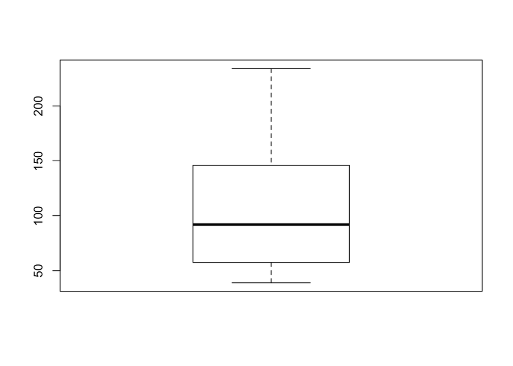

```r
#creates a boxplot with max and min and iqr and median
boxplot(chx_wt$Weight)
```

# Part 2

## 2) Functions

### a) Use the files from lab 1 to compute mean values for each variable using ‘apply’

```r
#apply, "2" is columnwise
apply(chx_wt, 2, mean)
```

```
##     Weight     DayOld    ChickID     DietID
## 106.833333   9.000000  27.777778   2.333333
```

```r
apply(loblolly, 2, mean)
```

```
##   height      age     Seed
##  32.3644  13.0000 316.1429
```

### b) Write a function ‘f’ that behaves like this:

> f(‘Jim’)

> [1] “hello Jim, how are you”

```r
#function asks for a name and paste it into a sentence
f <- function(name) {
  x <- paste0("hello ", name, ", how are you") #paste0 means no spaces
  return(x)
}

f("Jim")
```

```
## [1] "hello Jim, how are you"
```

### c) Write a function ‘sumOfSquares’ that behaves like this:

> d <- c(1,5,2,4,6,2,4,5)

> sumOfSquares(d)

> [1] 21.875

```r
#subtracts the mean value of all numbers from each number, squares them and sums them
sumOfSquares <- function(n) {
    x <- sum((n - mean(n))^2)
    return(x)
}

#create a vector of numbers
d <- c(1,5,2,4,6,2,4,5)

#pass to the function
sumOfSquares(d)
```

```
## [1] 21.875
```

To compute the “sum of squares”, subtract the mean value of all numbers from each number. Square these numbers and sum them

## 3) Data preparation.

Use the data in “students.csv” and “scores.dat” to assess if there is a relation between the “group” or “age” of a student and their average score and for the three subjects (math, english, geography)

```r
#read in the data
students <- read.csv("./data/students.csv")

#scores has -999 as a value, replace with NA for later removal from calculations
scores <- read.table("./data/scores.dat", header = TRUE, na.strings = "-999")

head(students)
```

```
##   students group age
## 1        A     1  25
## 2        B     1  20
## 3        C     1  20
## 4        D     2  22
## 5        E     1  25
## 6        F     1  19
```

```r
head(scores)
```

```
##   student   subject score
## 1       A      math  10.0
## 2       A   english  10.0
## 3       A geography   5.2
## 4       B      math   6.6
## 5       B   english   5.8
## 6       B geography   4.1
```

### a) use reshape and merge to combine the two data sets

```r
#reshape the data from long to wide
scores_reshape <- reshape(scores, idvar = "student", timevar = "subject", direction = "wide")

#did that work?
head(scores_reshape) #yes
```

```
##    student score.math score.english score.geography
## 1        A       10.0          10.0             5.2
## 4        B        6.6           5.8             4.1
## 7        C        5.4           7.2             5.4
## 10       D        8.1           8.5            10.5
## 13       E        7.5          10.0             8.5
## 16       F         NA           6.6             6.6
```

```r
#merge joinkey is students in students and student in the reshape
student_scores <- merge(students, scores_reshape, by.x = "students", by.y = "student")

#check it out
head(student_scores)
```

```
##   students group age score.math score.english score.geography
## 1        A     1  25       10.0          10.0             5.2
## 2        B     1  20        6.6           5.8             4.1
## 3        C     1  20        5.4           7.2             5.4
## 4        D     2  22        8.1           8.5            10.5
## 5        E     1  25        7.5          10.0             8.5
## 6        F     1  19         NA           6.6             6.6
```

### b) compute correlation coefficients

```r
#minus the first column because it's not a number, complete.obs excludes na
cor(student_scores[,-1], use = "complete.obs")
```

```
##                       group        age   score.math score.english
## group            1.00000000  0.0306478 -0.285206998   0.084006433
## age              0.03064780  1.0000000 -0.141486491   0.452093676
## score.math      -0.28520700 -0.1414865  1.000000000   0.002720296
## score.english    0.08400643  0.4520937  0.002720296   1.000000000
## score.geography  0.27422128 -0.2357200  0.137538316  -0.034782010
##                 score.geography
## group                0.27422128
## age                 -0.23572004
## score.math           0.13753832
## score.english       -0.03478201
## score.geography      1.00000000
```

### c) produce a relevant plot

Scatterplot Matrix

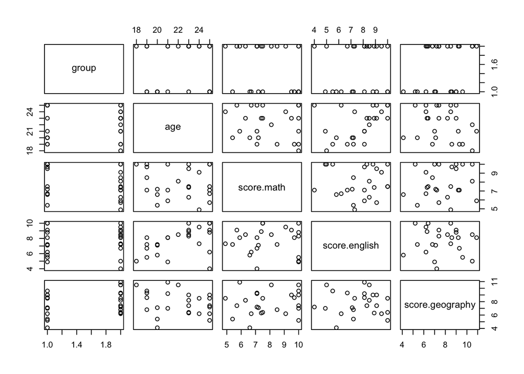

```r
#create a scatterplot matrix of variables
pairs(group ~ age + score.math + score.english + score.geography, student_scores, na.action = na.omit)
```

Scores by Age

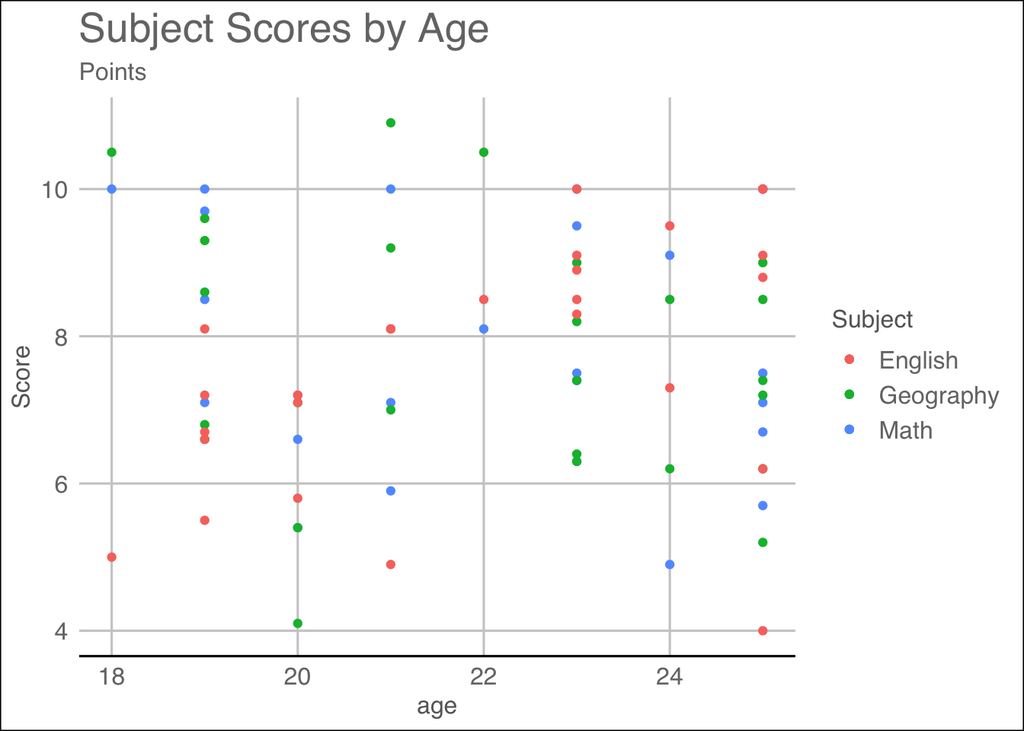

```r
library(ggplot2)
library(ggthemes)
#using geom point to plot each subject score by Age
ggplot(student_scores, aes(x = age, y = Score)) +
  geom_point(aes(y = score.math, color = "Math")) +
  geom_point(aes(y = score.geography, color = "Geography")) +
  geom_point(aes(y = score.english, color = "English")) +
  labs(color = "Subject", title = "Subject Scores by Age", subtitle = "Points") +
  theme_gdocs()
```

Points are hard to read, let’s try smoothed means

```
## Warning: Removed 1 rows containing non-finite values (stat_smooth).
```

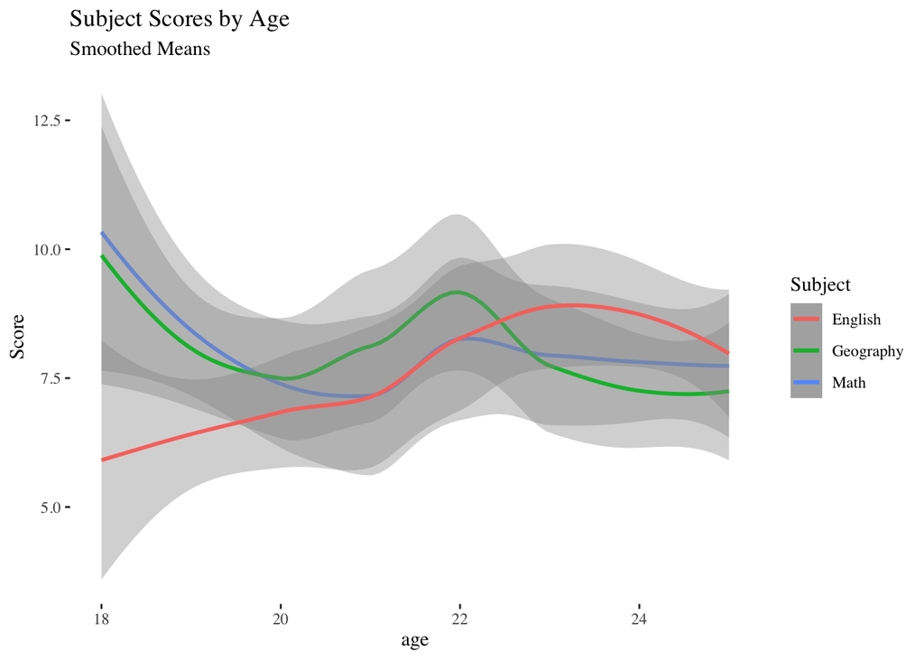

```r
#using geom smooth to plot each subject score by Age
ggplot(student_scores, aes(x = age, y = Score)) +
  geom_smooth(aes(y = score.math, color = "Math")) +
  geom_smooth(aes(y = score.geography, color = "Geography")) +
  geom_smooth(aes(y = score.english, color = "English")) +
  labs(color = "Subject", title = "Subject Scores by Age", subtitle = "Smoothed Means") +
  theme_tufte()
```